# Презентация по Этапу №1 индивидуального проекта

Основы информационной безопасности

Татьяна Александровна Пономарева

Российский университет дружбы народов

2026-03-07

# Информация

## Докладчик

- Пономарева Татьяна Александровна
- Студент группы НКАбд-04-24
- Российский университет дружбы народов им. П. Лумумбы
- taponomareva6742@gmail.com
- https://github.com/taponomareva

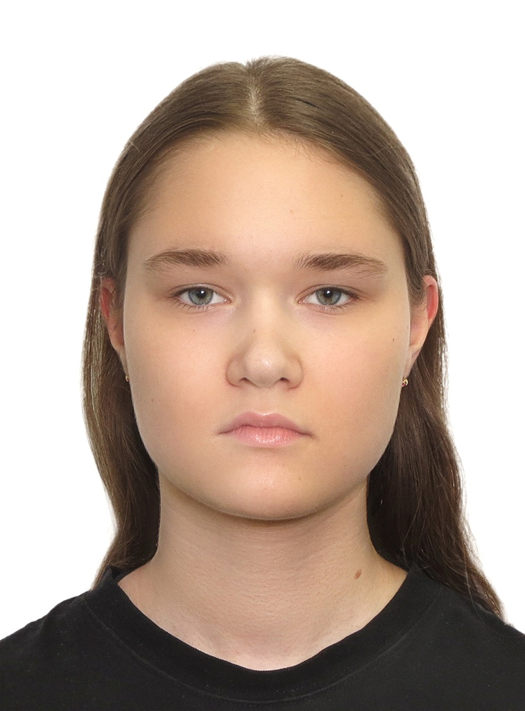

# Вводная часть

## Цель работы

Целью данной работы является приобретение практических навыков установки операционной системы на виртуальную машину, настройки минимально необходимых для дальнейшей работы сервисов.

## Задание

Установить дистрибутив Kali Linux и установить соответствующие параметры для виртуальной машины.

# Теоретическое введение

Kali Linux - это дистрибутив Linux, предназначенный для тестирования на проникновение (пентестинга) и других задач информационной безопасности. Он содержит широкий набор инструментов и функций, позволяющих специалистам по кибербезопасности выявлять и устранять уязвимости в системах и сетях [1].

Название «Kali Linux» вдохновлено именем индуистской богини Кали, а на логотипе изображён дракон. Эти символы отражают силу, мудрость и изменения, а также подчёркивают миссию дистрибутива — предоставление мощных инструментов для улучшения безопасности информационных систем [2].

# Выполнение работы

## Образ Kali Linux

Сначала скачиваем образ Kali Linux (рис. 1).

[figure not shown]

Рисунок 1: Образ Kali Linux

## Открытая программа Virtual Box

Потом открываем Virtual Box (рис. 2).

[figure not shown]

Рисунок 2: Открытая программа Virtual Box

## Создание новой виртуальной машины

Создаем новую виртуальную машину на образе Kali Linux (рис. 3).

[figure not shown]

Рисунок 3: Создание новой виртуальной машины

## Настройка параметров виртуального оборудования

Указываем виртуальное оборудование (рис. 4).

[figure not shown]

Рисунок 4: Настройка параметров виртуального оборудования

## Задание размера жесткого диска

Задаем размер жесткого диска (рис. 5).

[figure not shown]

Рисунок 5: Задание размера жесткого диска

## Окно виртуальной машины

Запускаем виртуальную машину, которая была установлена на образе Kali Linux (рис. 6).

[figure not shown]

Рисунок 6: Окно виртуальной машины

## Настройка языка системы

Выбираем язык установки, на котором будет машина (рис. 7).

[figure not shown]

Рисунок 7: Настройка языка системы

## Задание имени хоста

Потом задаем имя хоста, в моем случае - это taponomareva (рис. 8).

[figure not shown]

Рисунок 8: Задание имени хоста

## Задание имени домена

Далее задаем имя домена (рис. 9).

[figure not shown]

Рисунок 9: Задание имени домена

## Задание имени учетной записи

Затем задаем имя учетной записи системы (рис. 10).

[figure not shown]

Рисунок 10: Задание имени учетной записи

## Задание имени пользователя

Потом задаем имя пользователя (рис. 11).

[figure not shown]

Рисунок 11: Задание имени пользователя

## Пароль

Настраиваем пароль (рис. 12).

[figure not shown]

Рисунок 12: Пароль

## Место на жестком диске

Разделяем место на жестком диске опциями (рис. 13).

[figure not shown]

Рисунок 13: Место на жестком диске

## Настройка распределения места на жестком диске часть 1

[figure not shown]

Рисунок 14: Настройка распределения места на жестком диске часть 1

## Настройка распределения места на жестком диске часть 2

Продолжаем настройку разделения места на жестком диске (рис. 15).

[figure not shown]

Рисунок 15: Настройка распределения места на жестком диске часть 2

## Настройка распределения места на жестком диске часть 3

Видим, что система показывает, как она будет разделять виртуальную память (рис. 16).

[figure not shown]

Рисунок 16: Настройка распределения места на жестком диске часть 3

## Изменения в форматировании

Вносим изменения в форматировании (рис. 17).

[figure not shown]

Рисунок 17: Изменения в форматировании

## Установка дополнительных сред

Устанавливаем рекомендованные программы и средства (рис. 18).

[figure not shown]

Рисунок 18: Установка дополнительных сред

## Установка загрузчика системы

Устанавливаем загрузчик системы (рис. 19).

[figure not shown]

Рисунок 19: Установка загрузчика системы

## Перезагрузка

Перезагружаем машину (рис. 20).

[figure not shown]

Рисунок 20: Перезагрузка

## Вход в систему

При повторном запуске вводим имя пользователя и пароль (рис. 21).

[figure not shown]

Рисунок 21: Вход в систему

## Рабочий стол Kali Linux

Далее видим рабочий стол Kali Linux, что показывает правильность установки (рис. 22).

[figure not shown]

Рисунок 22: Рабочий стол Kali Linux

# Выводы

При ходе работы были приобретены практические навыки установки операционной системы на виртуальную машину, настройки минимально необходимых для дальнейшей работы сервисов.

# Список литературы

1. Kali Linux: полное руководство для начинающих [Электронный ресурс]. Fox- mindED. URL: https://foxminded.ua/ru/kali-linuks/ (дата обращения: 07.03.2025).
2. Kali Linux: обзор дистрибутива для будущих хакеров [Электронный ресурс]. Skillbox. URL: https://skillbox.ru/media/code/kali-linux-obzor-distributiva-dlya- budushchikh-khakerov/ (дата обращения: 07.03.2025).